# Analysis Workflow Genomic Prediction/Selection

Waseem Hussain, Senior Scientist IRRI[^1]

2024-10-25

# Load the Libraries

```r
> # Load the Required Libraries
>   rm(list=ls()) # Remove previous work
>   library(rrBLUP)
>   library(BGLR)
>   library(AGHmatrix)
>   library(ggplot2)
>   library(DT)
>   #library(cvTools)
>   library(dplyr)
>   library(lme4)
>   library(arm)
>   library(sommer)
```

# Two Step Genomic Selection

- Here will show example of **Two-step Genomic selection**, in which non-genetic effects and genetic effects are modeled seperately. More details on on single-step and two-step GS can be found here: [Resource 1](https://doi.org/10.1002/csc2.20253), [Resource 2](https://doi.org/10.1371/journal.pone.0201181), [Resource 3](https://doi.org/10.1534/g3.118.200038), [Resource 4](https://www.nature.com/articles/s41437-020-0321-0).
- Here in this section we will provide an example how to fit the model when we have marker data available. We will show how to extract the breeding values.
- We will use data from the trials evaluated under high temperature across multiple countries
- We will use the the BLUEs as response variable which has been already estimated per trial.

# Read SNP Marker Data

- Genotype/marker data is GBS data set with 844 genotypes and 396511 SNP Markers

```r
>   geno<-readRDS("./Data_sets/GBS_data.rds")
>   dim(geno)
[1]    844 396511
```

## Read the Phenotype Data

```r
>   pheno<-read.csv(file="./Data_sets/BLUEs.all.csv", header=TRUE, row.names = 1)
>   pheno<-na.omit(pheno)
>   # Subset the data and remove IRRI data
>   pheno$ExperimentalSite<-as.factor(pheno$ExperimentalSite)
>   pheno2<-pheno[! pheno$ExperimentalSite %in% c('IRRICT', 'IRRIHNT'), ]
>   pheno2<-droplevels.data.frame(pheno2)
>   table(pheno2$ExperimentalSite)

  BDLalpur   BDTanore  MMKyaukse MMPangkone    MMYezin
       251        252        252        252        252
>   Ids<-unique( pheno2$IRDNC_ID)
>   length(Ids)
[1] 252
>   # Now subet the genotype Data based on IDs
>   geno<-geno[row.names(geno)%in%Ids,]
>   dim(geno)
[1]    252 396511
```

# Now Build the gBLUP model

## Build the G matrix

- Here we will construct the **Genomic Relationship Matrix (GRM)** using marker data. The GRM will be based on **VanRanden (2008)**.
- The steps used to create this GRM is:
  - Create a center of marker data (X matrix)
  - Create a Cross Product $(XX)$
  - Divide the $(XX)$ by number of markers

  $$GRM= XX^t/m$$
- More on relationship matrix can be found here [Source 1](https://www.sciencedirect.com/science/article/pii/S0022030209707933), [Source2](https://naldc.nal.usda.gov/download/27183/PDF)
- We will use the AGHmatrix package to build G matrix.

```r
>   GM<- Gmatrix(SNPmatrix=geno, missingValue=NA,
+                             maf=0.05, method="VanRaden")
Initial data:
    Number of Individuals: 252
    Number of Markers: 396511

Missing data check:
    Total SNPs: 396511
     0 SNPs dropped due to missing data threshold of 0.5
    Total of: 396511  SNPs

MAF check:
     24891 SNPs dropped with MAF below 0.05
    Total: 371620  SNPs

Heterozigosity data check:
    No SNPs with heterozygosity, missing threshold of =  0

Summary check:
    Initial:  396511 SNPs
    Final:  371620  SNPs ( 24891  SNPs removed)

Completed! Time = 31.571  seconds
>   dim(GM)
[1] 252 252
```

## Heat Map of the GM matrix

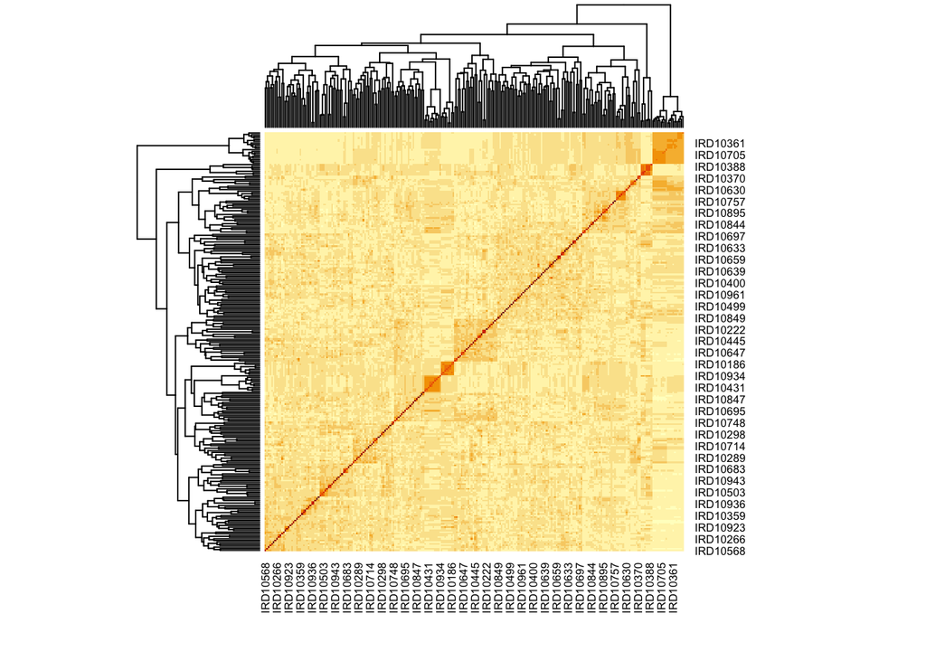

```r
>   heatmap(GM)
```

# Fit the Model

- The baseline **GBLUP** model is given as:

$$y = X\beta+Zu + e$$
where $y$ is the vector of BLUEs or response variable; $\beta$ represents the fixed effects; $X$ is the design matrix of fixed effects, $u$ is the vector of random marker effects, where $u \sim N(0,I\sigma^2_u)$ and $\sigma^2_u$ is the marker variance; and $e$ is residuals, where $e \sim N(0,I\sigma^2_{\epsilon})$. $Z$ is the design matrix of $m$ markers.

- Note we will use the **G Matrix** rather than Marker design matrix to fit the gBLUP model.
- Note in GBLUP model $u$ represent the *Genomic Estimated Breeding Values **not marker effects. It is called** BLUP of Breeding Value**
- We will use *SOMMER* R package (Click Here)[https://cran.r-project.org/web/packages/sommer/index.html]

```r
>   library(sommer)
> # Write the model
>   g_blup<- mmer(BLUEs~1,
+               random=~vsr(IRDNC_ID,Gu=GM)+ExperimentalSite,
+               rcov=~units, nIters=3,data=pheno2,verbose = FALSE)
>   summary(g_blup)
==============================================================
          Multivariate Linear Mixed Model fit by REML
***********************  sommer 4.3  ***********************
==============================================================
         logLik      AIC      BIC Method Converge
Value -127.2639 256.5277 261.6658     NR    FALSE
==============================================================
Variance-Covariance components:
                             VarComp VarCompSE Zratio Constraint
u:IRDNC_ID.BLUEs-BLUEs         19966      7437  2.685   Positive
ExperimentalSite.BLUEs-BLUEs  843215    521267  1.618   Positive
units.BLUEs-BLUEs             536007     22730 23.581   Positive
==============================================================
Fixed effects:
  Trait      Effect Estimate Std.Error t.value
1 BLUEs (Intercept)     2356     411.2    5.73
==============================================================
Groups and observations:
                 BLUEs
u:IRDNC_ID         252
ExperimentalSite     5
==============================================================
Use the '$' sign to access results and parameters
>   #BLUPs<-g_blup$U$`u:IRDNC_ID`$BLUEs
>  # g_blup$Beta[1,3]
>   estimated<-data.frame(GEBVs= g_blup$U$`u:IRDNC_ID`$BLUEs)
>   estimated$GEBVs<-estimated$GEBVs+ g_blup$Beta[1,3]
```

# Example of Genomic Selection in Program

## Read the marker data

```r
> # Read the same marker data
>   geno<-readRDS("./Data_sets/GBS_data.rds")
>   dim(geno)
[1]    844 396511
```

```
  GM<- Gmatrix(SNPmatrix=geno, missingValue=NA,
                            maf=0.05, method="VanRaden")
  dim(GM)
```

```r
>   gs.model1<- mmer(BLUEs~1,
+               random=~vsr(IRDNC_ID,Gu=GM)+ExperimentalSite,
+               rcov=~units, nIters=3,data=pheno2,verbose = FALSE)
>   summary(gs.model1)
==============================================================
          Multivariate Linear Mixed Model fit by REML
***********************  sommer 4.3  ***********************
==============================================================
         logLik      AIC      BIC Method Converge
Value -127.2639 256.5277 261.6658     NR    FALSE
==============================================================
Variance-Covariance components:
                             VarComp VarCompSE Zratio Constraint
u:IRDNC_ID.BLUEs-BLUEs         19966      7437  2.685   Positive
ExperimentalSite.BLUEs-BLUEs  843215    521267  1.618   Positive
units.BLUEs-BLUEs             536007     22730 23.581   Positive
==============================================================
Fixed effects:
  Trait      Effect Estimate Std.Error t.value
1 BLUEs (Intercept)     2356     411.2    5.73
==============================================================
Groups and observations:
                 BLUEs
u:IRDNC_ID         252
ExperimentalSite     5
==============================================================
Use the '$' sign to access results and parameters
>   #gs.model1$U$`u:IRDNC_ID`$BLUEs
>   #gs.model1$Beta[1,3]
>   estimated<-data.frame(GEBVs= gs.model1$U$`u:IRDNC_ID`$BLUEs)
>   estimated$GEBVs<-estimated$GEBVs+ gs.model1$Beta[1,3]
```

## Visualize the GEBVs

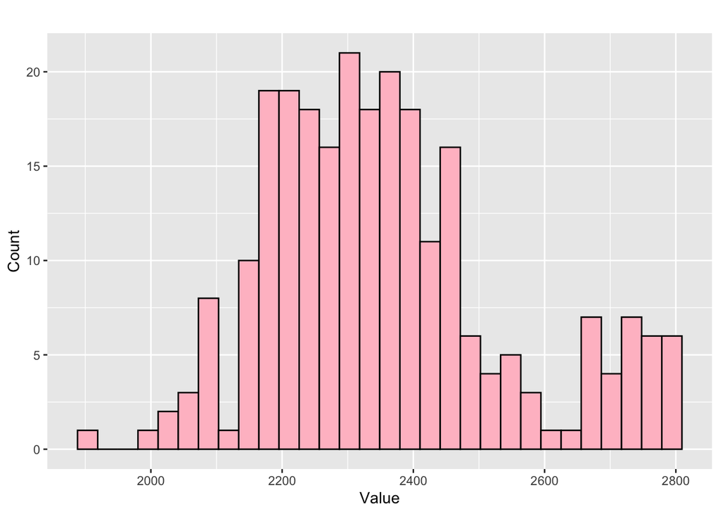

```r
> ggplot(data=estimated, aes(GEBVs))+
+           #geom_density(alpha = 0.5)+
+           geom_histogram(fill="pink", color="black")+
+           #theme_few()+ #use white theme
+           labs(title="",x="Value", y = "Count")
```

## Extract the Additional Components

### Variance Componnets

```r
> #var comps
> sm <- summary( gs.model1)$varcomp
> sm
                               VarComp  VarCompSE    Zratio Constraint
u:IRDNC_ID.BLUEs-BLUEs        19965.85   7436.814  2.684731   Positive
ExperimentalSite.BLUEs-BLUEs 843215.34 521266.923  1.617627   Positive
units.BLUEs-BLUEs            536007.42  22730.500 23.580978   Positive
```

### Heritability

```r
> vg <- sm[grepl('IRDNC_ID', row.names(sm)), 1]
> ve <- sm[grepl('units', row.names(sm)), 1]
> h2 <- vpredict(gs.model1, h2 ~ V1 / (V1 + V2))$Estimate
> h2
[1] 0.02313054
attr(,"gradient")
               V1            V2 V3
[1,] 1.131708e-06 -2.679685e-08  0
```

### Reliability (Prediction Accuracy)

```r
> # Get prediction Error Variance
> pev <- diag(gs.model1$PevU$`u:IRDNC_ID`$BLUEs)
> # Get Reliability
> reliability<- data.frame(r2=1 - pev / vg)
> head(reliability)
                 r2
IRD10162 -0.2968483
IRD10164  0.1885750
IRD10169 -0.3279268
IRD10173 -0.2273789
IRD10175 -0.3975196
IRD10176 -0.4007059
```

# Additional Literature

- [Screening experimental designs](https://www.frontiersin.org/articles/10.3389/fphys.2012.00156/full)
- [Analysis and Handling of G × E in a Practical Breeding Program](https://acsess.onlinelibrary.wiley.com/doi/abs/10.2135/cropsci2015.06.0336)
- [A stage‐wise approach for the analysis of multi‐environment trials](https://onlinelibrary.wiley.com/doi/abs/10.1002/bimj.201100219)
- [Analysis of series of variety trials with perennial crops](https://onlinelibrary.wiley.com/doi/abs/10.1111/gfs.12054)
- [A tutorial on the statistical analysis of factorial experiments with qualitative and quantitative treatment factor levels](https://onlinelibrary.wiley.com/doi/full/10.1111/jac.12267)
- [Experimental design matters for statistical analysis: how to handle blocking](https://onlinelibrary.wiley.com/doi/abs/10.1002/ps.4773)
- [Random effects structure for confirmatory hypothesis testing: Keep it maximal](https://www.sciencedirect.com/science/article/abs/pii/S0749596X12001180)
- [Generalized linear mixed models: a practical guide for ecology and evolution](https://www.sciencedirect.com/science/article/abs/pii/S0169534709000196)
- [Mixed Models Offer No Freedom from Degrees of Freedom](https://www.sciencedirect.com/science/article/abs/pii/S0169534719303465)
- [Perils and pitfalls of mixed-effects regression models in biology](https://peerj.com/articles/9522/)
- [A brief introduction to mixed effects modelling and multi-model inference in ecology](https://peerj.com/articles/4794/)
- [Modeling Spatially Correlated and Heteroscedastic Errors in Ethiopian Maize Trials](https://acsess.onlinelibrary.wiley.com/doi/abs/10.2135/cropsci2017.11.0693)
- [More, Larger, Simpler: How Comparable Are On‐Farm and On‐Station Trials for Cultivar Evaluation](https://acsess.onlinelibrary.wiley.com/doi/abs/10.2135/cropsci2017.09.0555)
- [Rethinking the Analysis of Non‐Normal Data in Plant and Soil Science](https://acsess.onlinelibrary.wiley.com/doi/10.2134/agronj2013.0342)
- [The Design and Analysis of Long‐Term Rotation Experiments](https://acsess.onlinelibrary.wiley.com/doi/10.2134/agronj2012.0411)
- [Analysis of Combined Experiments Revisited](https://acsess.onlinelibrary.wiley.com/doi/10.2134/agronj13.0485)
- [Fundamentals of Experimental Design: Guidelines for Designing Successful Experiments](https://acsess.onlinelibrary.wiley.com/doi/full/10.2134/agronj2013.0114)

*Note: For questions specific to data analysiss shown here contact waseem.hussain@irri.org*

*If your experiment needs a statistician, you need a better experiment - Ernest Rutherford*

[^1]: IRRI,Rice Breeding Innovations, waseem.hussain@irri.org